# PA1_templateRev2

pmp

Thursday February 12, 2015

# REPRODUCIBLE RESEARCH - Peer Assessment Project 1

## Introduction

As stated in the introduction to this assignment, *[the] assignment makes use of data from a personal activity monitoring device. This device collects data at 5 minute intervals through out the day. The data consists of two months of data from an anonymous individual collected during the months of October and November, 2012 and include the number of steps taken in 5 minute intervals each day*.

## Loading & Processing Data

The data-set for the assignment was supplied as a zipped file called *Activtiy monitoring data.zip* and the data stored in a variable named “activity”.

```r
filename <- "./activity.csv"
activity <- read.csv(filename)
```

This project rises 4 questions regarding the activity data-set whose answers form the core of this report:

- What is total number of steps taken per day together with its mean and median values?
- What is the average daily activity pattern?
- Missing values and the effect of imputing for missing values
- Are there differences in activity patterns between weekdays and weekends?

## Data Explaration

```
##      steps                date          interval
##  Min.   :  0.00   2012-10-01:  288   Min.   :   0.0
##  1st Qu.:  0.00   2012-10-02:  288   1st Qu.: 588.8
##  Median :  0.00   2012-10-03:  288   Median :1177.5
##  Mean   : 37.38   2012-10-04:  288   Mean   :1177.5
##  3rd Qu.: 12.00   2012-10-05:  288   3rd Qu.:1766.2
##  Max.   :806.00   2012-10-06:  288   Max.   :2355.0
##  NA's   :2304     (Other)   :15840
```

The data-set contains three variables representing:

.steps: Number of steps recorded in a 5-minute interval (missing values are coded as NA)

.date: The date on which the measurement was taken in YYYY-MM-DD format

.interval: Identifier for the 5-minute interval in which measurement was taken

## Removing NA values

Histograms representing the distribution of number of steps per interval for each of the 61 days, show a similar range in the frequency distribution values, as well as, in the number of steps per interval.The differences among steps per day, however, are more apparent if the log base 10 of the number of steps per interval are used:

Figure 1

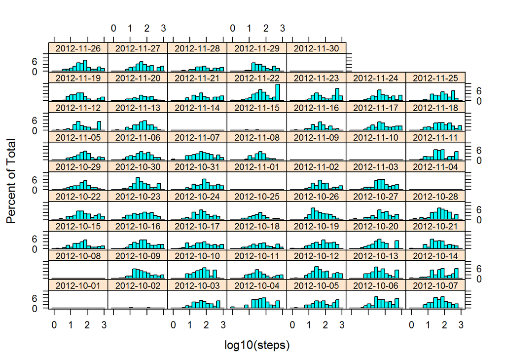

### Data set without missing values

```
##      steps                date          interval
##  Min.   :  0.00   2012-10-02:  288   Min.   :   0.0
##  1st Qu.:  0.00   2012-10-03:  288   1st Qu.: 588.8
##  Median :  0.00   2012-10-04:  288   Median :1177.5
##  Mean   : 37.38   2012-10-05:  288   Mean   :1177.5
##  3rd Qu.: 12.00   2012-10-06:  288   3rd Qu.:1766.2
##  Max.   :806.00   2012-10-07:  288   Max.   :2355.0
##                   (Other)   :13536
```

## Analysis and Data Query:

### What is the total number of steps taken per day?

The number of steps per day are compared among the 53 days of measurments in the bar graph below:

Figure 2.

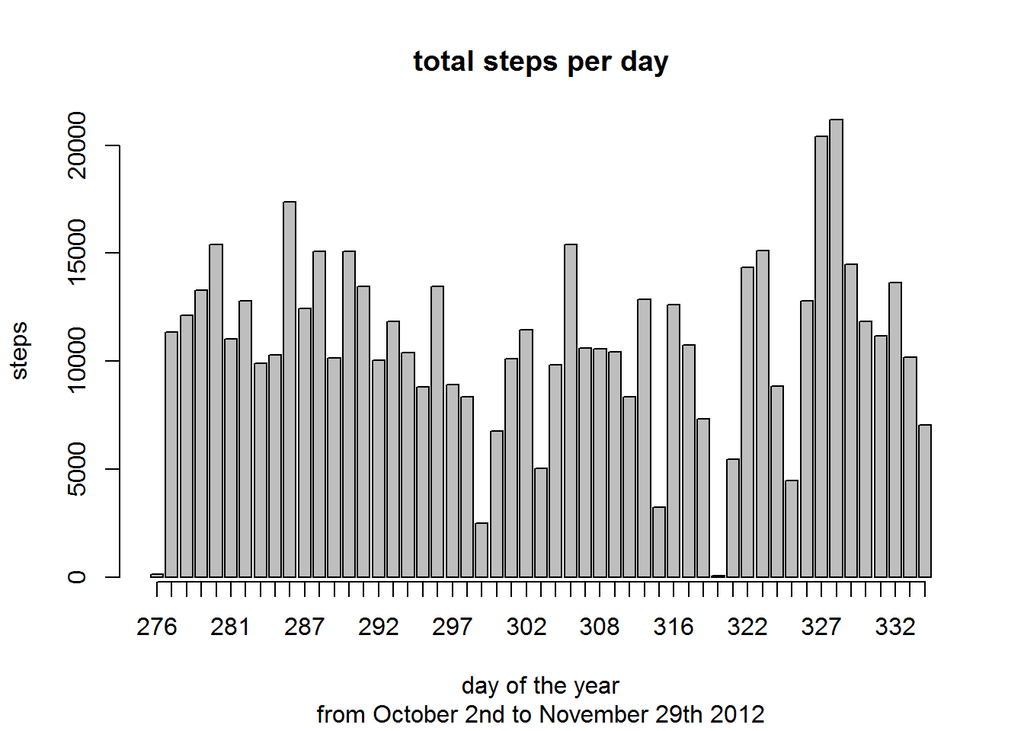

The mean and median values for the number of steps per day were calculated from the sum of steps for all intervals in a given day, and its distribution of values is shown in the histogram below:

Figure 3.

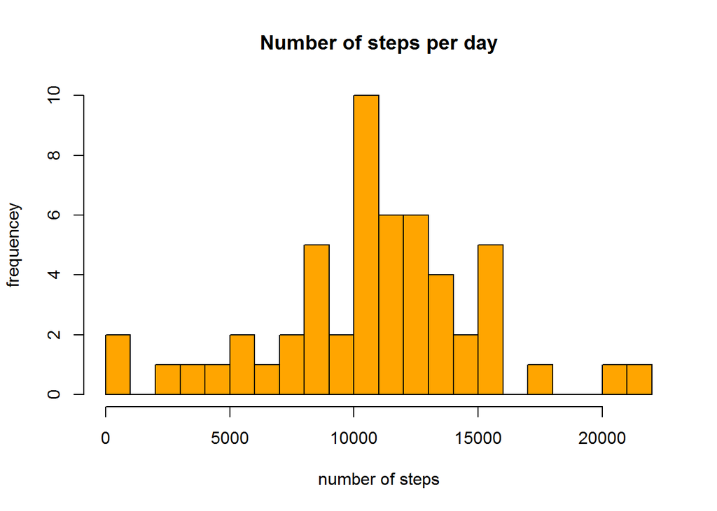

For comparison, the mean and median steps per interval, were also calculated

as shown in the table below

Table 1.

```
##   - mean per day +/- sdev per day - median per day - mean per interval
## 1       10766.19          4269.18            10765             37.3826
##   -median per interval-
## 1                     0
```

## What is the average daily activity pattern?

A time series plot of the 5-minute interval (x-axis) and the average number of steps taken, averaged across all days (y-axis) shows the following pattern:

Figure 4.

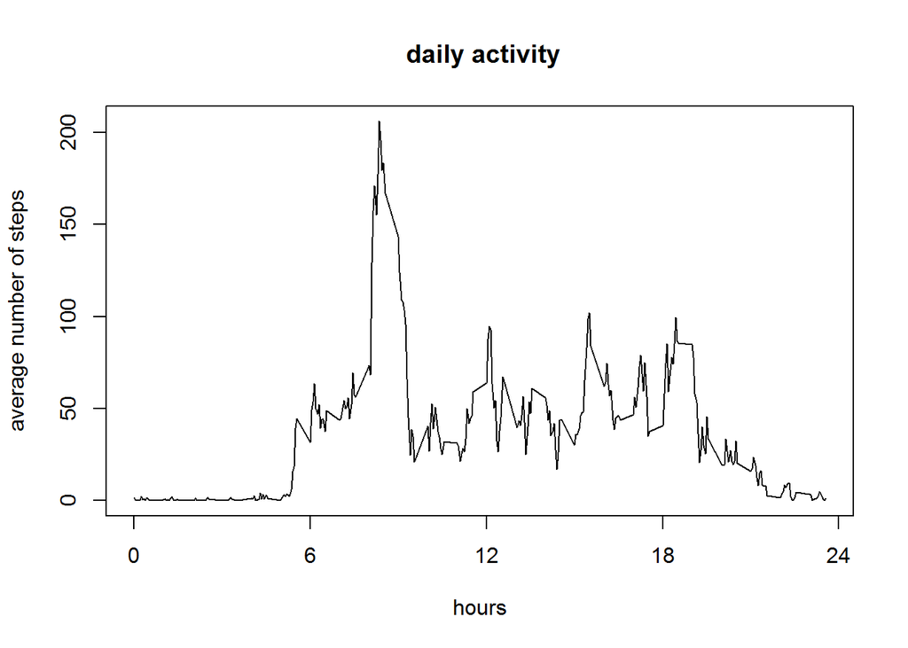

With the 104th interval, corresponding to the 8:35am interval, showing the highest mean step activity from October to November 2012 for the given monitored individual as 206.1698113.

## Imputing missing values

Imputation is a process used to generate values to replace NA missing values in a data-set. The use of imputation depends on the nature of the data [Missing data imputation](http://www.stat.columbia.edu/~gelman/arm/missing.pdf).

In this particular data set the total number of NA is relatively high at 2304 NAs. As an example of the imputation process, and how the methods used might or might not introduce changes in the general statistics of the data, I will use two imputation methods, one based on the mean and a second one based on a random selection of values to replace missing values.The techniques are borrowed from [Thomas Leeper](http://thomasleeper.com/Rcourse/Tutorials/NAhandling.html).

A new imputed data-set named “activity2” is based on mean value substitutions:

and a new data-set named “activity3” is based on random selection values method (RSVM) replacement imputation

### Comparisons of the two imputatation methods vs the original data

First, in Figure 5. we see a set of histograms in terms of the distributions of the log 10 step numbers per interval per day in terms of the original data compared to the RSVM imputed data :

Figure 5.

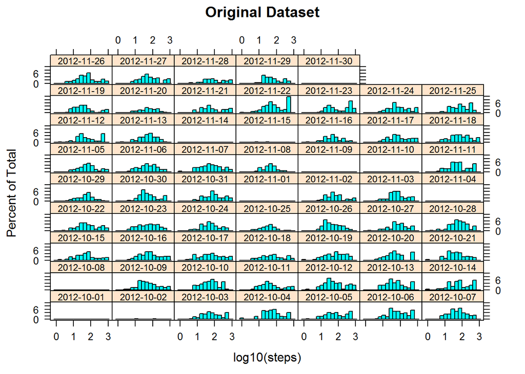

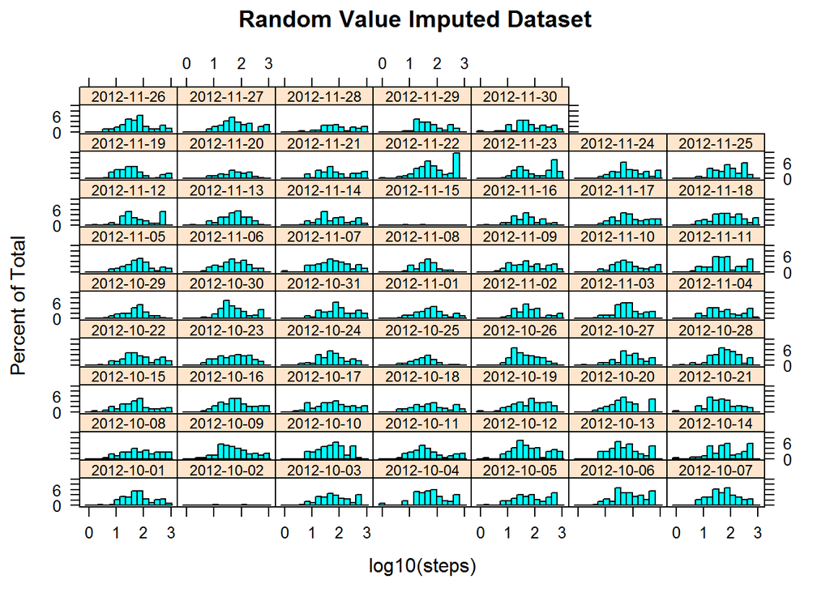

we can noticed that the random selection values method (RSVM) fills in those days with missing data with similarly distributed frequency distributions as those observed for other days, suggesting that the RSV imputation method recreates the frequency distribution observed in the original data fairly well.

The use of the mean value imputation, in Figure 6., alters the distribution patterns for the days with missing values introducing a single biased mean value:

Figure 6.

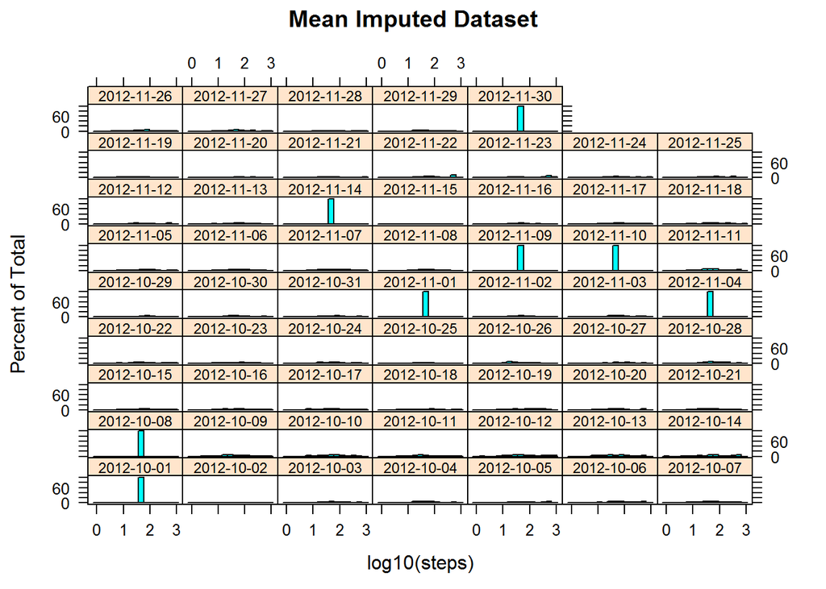

Second, one can compare the distributions of steps per day between the original dataset and the RSV imputation dataset as shown in the plot below (Figure7.):

Figure 7.

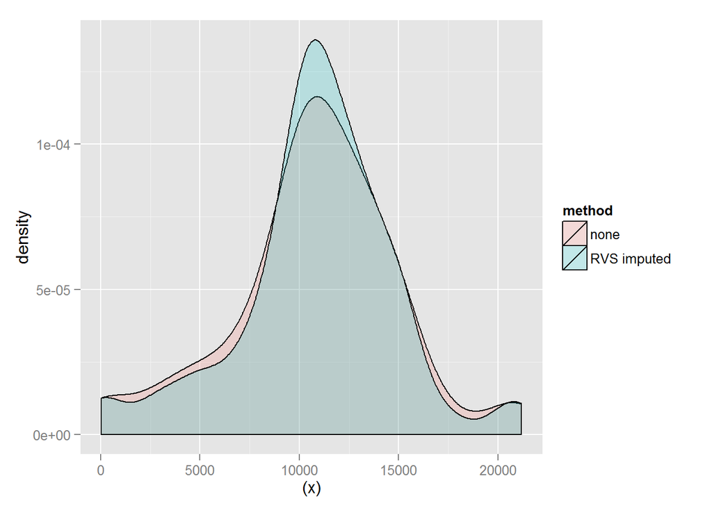

the plot shows that, as would be expected, the total number of steps is increased in the RSV imputed data set compared to the original data set (we have added entries to the missing values). From the distributions, the RSV imputed data set seems to be a valid correction of missing values as seeen by the distributions being very similar between the two data sets, although the RSV imputation has smoothed the original distribution eliminating some of the data-set’s non-normal random characteristics.

Table 2. Original Dataset

```
##      steps                date          interval
##  Min.   :  0.00   2012-10-02:  288   Min.   :   0.0
##  1st Qu.:  0.00   2012-10-03:  288   1st Qu.: 588.8
##  Median :  0.00   2012-10-04:  288   Median :1177.5
##  Mean   : 37.38   2012-10-05:  288   Mean   :1177.5
##  3rd Qu.: 12.00   2012-10-06:  288   3rd Qu.:1766.2
##  Max.   :806.00   2012-10-07:  288   Max.   :2355.0
##                   (Other)   :13536
```

Table 3. RSVM imputed dataset

```
##      steps               date          interval
##  Min.   :  0.0   2012-10-01:  288   Min.   :   0.0
##  1st Qu.:  0.0   2012-10-02:  288   1st Qu.: 588.8
##  Median :  0.0   2012-10-03:  288   Median :1177.5
##  Mean   : 37.7   2012-10-04:  288   Mean   :1177.5
##  3rd Qu.: 11.0   2012-10-05:  288   3rd Qu.:1766.2
##  Max.   :806.0   2012-10-06:  288   Max.   :2355.0
##                  (Other)   :15840
```

and the table below compares the mean +/- standard deviation of daily average steps between the imputed and original data set:

Table 4.

```
##   - mean per day +/- sdev per day - imputetd mean per day
## 1       10766.19          4269.18                10856.49
##   +/- sdev per day -
## 1           4022.514
```

## Are there differences in activity patterns between weekdays and weekends?

For the next query we are using the RVSM imputed data set for the analysis.

Before embarking in the presumption that there is a difference between weekday and weekend activities one needs to compare not only weekdays versus weekends as a whole but each week day versus each other:

The resulting plot bellow indicates that steps per five minute interval increases in the weekends and in the middle of the week. Without knowing the particular activities of the individual monitored, the elevated average number of steps per interval on a Wednesday could also be due to an increased stepping tempo. It is also evident that the “weekend” trend starts on Friday, a day that needs to be included as part of the weekend:

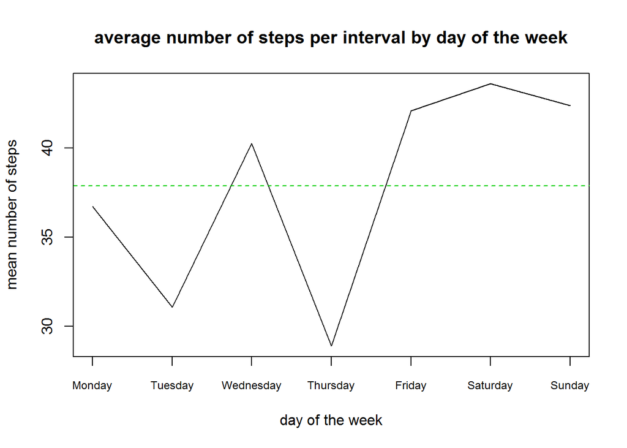

A better insight of the average weekly 24 hour activity pattern is shown in the next plot generated comparing the average day of the week 24 hour activity.

### Day of the week datasets:

### Plot of Day of the Week activities

Orange corresponds to the standard weekdays (Monday through Thursday) and blue corresponds to the weekend days (Friday through Sunday). The y scale is fixed between 0 and 350 steps.

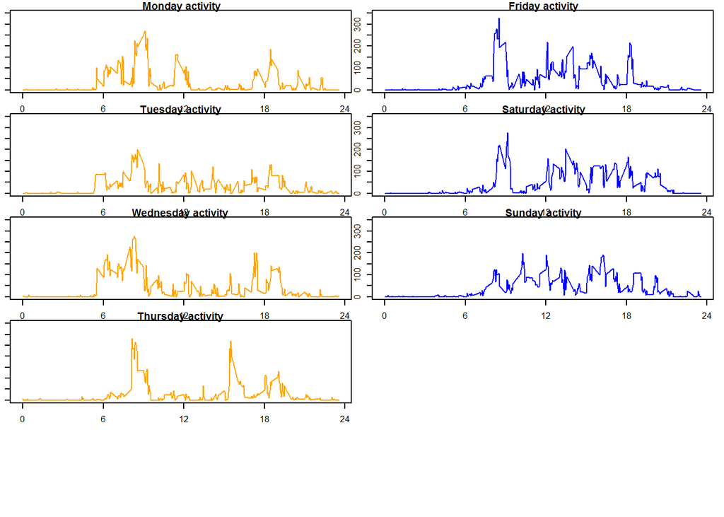

*Three main patterns are evident from the data:  
-Somewhere between 8am and 9am this individual performed the longest consecutive walk/run except for Sunday -Thursday is the day with the least number of steps but with two consecutive long walks/runs. -The weekend days have the highest overall daily activity.

### Are the differences between Weekdays and Weekend activity significant?

The next plot compares the average daily values for the weekdays vs the weekends.

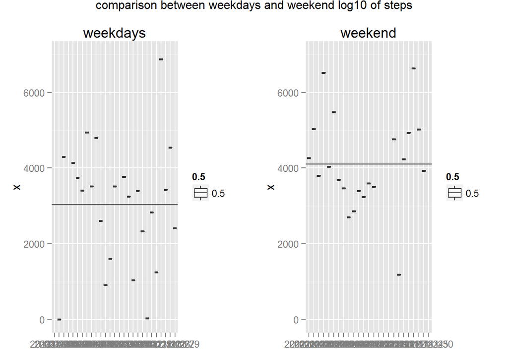

One can see a definite increase in the mean of the values, as well as, a bias towards larger numbers of steps during the weekend.

Furthermore, the mean per interval number of steps like the mean per daily steps is increased during the weekend, as shown in the table below: “Speedy Gonzales on the weekends!”

```
##   - mean per interval per weekday - mean per interval per weekend -
## 1                         31.5178                          42.78819
```

```
##   - mean per day per weekday   +/- SD - mean per day per weekend  +/- SD -
## 1                   3025.708 1636.366                   4107.667  1256.119
```